# Chapter 10

Iris

2020/4/26

## Question 1

Draw a function g(x) for which the fixed-point algorithm produces the oscillating sequence 1, 7, 1, 7, . . . when started with $x_{0} = 7$.

```r
rm(list = ls())
fixedpoint <- function(ftn, x0, tol = 1e-9, max.iter = 100){
  xold <- x0
  xnew <- ftn(xold)
  iter <- 1
  cat("At iteration 1 value of x is:", xnew, "\n")
  while ((abs(xnew-xold) > tol) && (iter < max.iter)) {
    xold <- xnew;
    xnew <- ftn(xold);
    iter <- iter + 1
    cat("At iteration", iter, "value of x is:", xnew, "\n")
  }
  if (abs(xnew-xold) > tol){
    cat("Algorithm failed to converge\n")
    return(NULL)
  }else{
    cat("Algorithm converged\n")
    return(xnew)
  }
}

ftn1 <- function(x) return(3*sin(x/2*pi)-4*cos(x*pi))
fixedpoint(ftn1, 7, tol = 1e-06)  #tol->計算後算到的小數位
```

```
## At iteration 1 value of x is: 1
## At iteration 2 value of x is: 7
## At iteration 3 value of x is: 1
## At iteration 4 value of x is: 7
## At iteration 5 value of x is: 1
## At iteration 6 value of x is: 7
## At iteration 7 value of x is: 1
## At iteration 8 value of x is: 7
## At iteration 9 value of x is: 1
## At iteration 10 value of x is: 7
## At iteration 11 value of x is: 1
## At iteration 12 value of x is: 7
## At iteration 13 value of x is: 1
## At iteration 14 value of x is: 7
## At iteration 15 value of x is: 1
## At iteration 16 value of x is: 7
## At iteration 17 value of x is: 1
## At iteration 18 value of x is: 7
## At iteration 19 value of x is: 1
## At iteration 20 value of x is: 7
## At iteration 21 value of x is: 1
## At iteration 22 value of x is: 7
## At iteration 23 value of x is: 1
## At iteration 24 value of x is: 7
## At iteration 25 value of x is: 1
## At iteration 26 value of x is: 7
## At iteration 27 value of x is: 1
## At iteration 28 value of x is: 7
## At iteration 29 value of x is: 1
## At iteration 30 value of x is: 7
## At iteration 31 value of x is: 1
## At iteration 32 value of x is: 7
## At iteration 33 value of x is: 1
## At iteration 34 value of x is: 7
## At iteration 35 value of x is: 1
## At iteration 36 value of x is: 7
## At iteration 37 value of x is: 1
## At iteration 38 value of x is: 7
## At iteration 39 value of x is: 1
## At iteration 40 value of x is: 7
```

[output cut: 46 more lines]

```
## At iteration 87 value of x is: 1
## At iteration 88 value of x is: 7
## At iteration 89 value of x is: 1
## At iteration 90 value of x is: 7
## At iteration 91 value of x is: 1
## At iteration 92 value of x is: 7
## At iteration 93 value of x is: 1
## At iteration 94 value of x is: 7
## At iteration 95 value of x is: 1
## At iteration 96 value of x is: 7
## At iteration 97 value of x is: 1
## At iteration 98 value of x is: 7
## At iteration 99 value of x is: 1
## At iteration 100 value of x is: 7
## Algorithm failed to converge
```

## Question 3

1.Use fixedpoint to find the fixed point of $cos x$. Start with $x_{0} = 0$ as your initial guess (the answer is 0.73908513).

```r
rm(list = ls())
#Chpater 10 page.5 function description:

fixedpoint <- function(ftn, x0, tol = 1e-9, max.iter = 100){
  # do first iteration
  xold <- x0
  xnew <- ftn(xold)
  iter <- 1
  cat("At iteration 1 value of x is:", xnew, "\n")

  # continue iterating until stopping conditions are met
  while ((abs(xnew-xold) > tol) && (iter < max.iter)) {
    xold <- xnew;
    xnew <- ftn(xold);
    iter <- iter + 1
    cat("At iteration", iter, "value of x is:", xnew, "\n")
  }

  # output depends on success of algorithm
  if (abs(xnew-xold) > tol){
    cat("Algorithm failed to converge\n")
    return(NULL)
  }else{
    cat("Algorithm converged\n")
    return(xnew)
  }
}

ftn1 <- function(x) return(cos(x))
fixedpoint(ftn1, 0, tol = 1e-06)
```

```
## At iteration 1 value of x is: 1
## At iteration 2 value of x is: 0.5403023
## At iteration 3 value of x is: 0.8575532
## At iteration 4 value of x is: 0.6542898
## At iteration 5 value of x is: 0.7934804
## At iteration 6 value of x is: 0.7013688
## At iteration 7 value of x is: 0.7639597
## At iteration 8 value of x is: 0.7221024
## At iteration 9 value of x is: 0.7504178
## At iteration 10 value of x is: 0.731404
## At iteration 11 value of x is: 0.7442374
## At iteration 12 value of x is: 0.7356047
## At iteration 13 value of x is: 0.7414251
## At iteration 14 value of x is: 0.7375069
## At iteration 15 value of x is: 0.7401473
## At iteration 16 value of x is: 0.7383692
## At iteration 17 value of x is: 0.7395672
## At iteration 18 value of x is: 0.7387603
## At iteration 19 value of x is: 0.7393039
## At iteration 20 value of x is: 0.7389378
## At iteration 21 value of x is: 0.7391844
## At iteration 22 value of x is: 0.7390183
## At iteration 23 value of x is: 0.7391302
## At iteration 24 value of x is: 0.7390548
## At iteration 25 value of x is: 0.7391056
## At iteration 26 value of x is: 0.7390714
## At iteration 27 value of x is: 0.7390944
## At iteration 28 value of x is: 0.7390789
## At iteration 29 value of x is: 0.7390893
## At iteration 30 value of x is: 0.7390823
## At iteration 31 value of x is: 0.739087
## At iteration 32 value of x is: 0.7390838
## At iteration 33 value of x is: 0.739086
## At iteration 34 value of x is: 0.7390845
## At iteration 35 value of x is: 0.7390855
## Algorithm converged
```

```
## [1] 0.7390855
```

2,Now use newtonraphson to find the root of $cos x − x$, starting with $x_{0} = 0$ as your initial guess.

```r
# Newton_Raphson algorithm for solving ftn(x)[1] == 0
newtonraphson <- function(ftn, x0, tol = 1e-9, max.iter = 100){
  # initialise
  x <- x0  # x0 is the initial guess at the root
  fx <- ftn(x)
  iter <- 0

  # continue iterating until stopping conditions are met
  while ((abs(fx[1]) > tol) && (iter < max.iter)){
    x <- x - fx[1]/fx[2]
    fx <- ftn(x)
    iter <- iter + 1
    cat("At iteration", iter, "value of x is:", x, "\n")
  }

  # output depends on success of algorithm
  if (abs(fx[1]) > tol){
    cat("Algorithm failed to converge\n")
    return(NULL)
  }else{
    cat("Algorithm converged\n")
    return(x)
  }
}

ftn4 <- function(x) {
  fx <- cos(x)-x
  dfx <- -sin(x)-1
  return(c(fx, dfx))
}
newtonraphson(ftn4, 0)
```

```
## At iteration 1 value of x is: 1
## At iteration 2 value of x is: 0.7503639
## At iteration 3 value of x is: 0.7391129
## At iteration 4 value of x is: 0.7390851
## Algorithm converged
```

```
## [1] 0.7390851
```

3.Is it faster than the fixed-point method?

By above results, we can see that newtonraphson is faster than the fixed-point method.

## Question 4

The function fixedpoint_show.r below is a modification of fixedpoint that plots intermediate results.  
Instead of using the variables tol and max.iter to determine when the algorithm stops,  
at each step you will be prompted to enter “y” at the keyboard if you want to continue.  
There are also two new inputs, xmin and xmax, which are used to determine the range of the plot.  
xmin and xmax have defaults $x_{0}$- 1 and $x_{0}$+ 1 , respectively.

function:

```r
fixedpoint_show <- function(ftn, x0, xmin = x0-1, xmax = x0+1){
  x <- seq(xmin, xmax, (xmax - xmin)/200)
  fx <- sapply(x, ftn)
  plot(x, fx, type = "l", xlab = "x", ylab = "f(x)",main = "fixed point f(x) = x", col = "blue", lwd = 2)
  lines(c(xmin, xmax), c(xmin, xmax), col = "blue")
  xold <- x0
  xnew <- ftn(xold)
  lines(c(xold, xold, xnew), c(xold, xnew, xnew), col = "red")
  lines(c(xnew, xnew), c(xnew, 0), lty = 2, col = "red")
  cat("last x value", xnew, " ")
  continue <- readline("continue (y or n)? ") == "y"
  while (continue){
    xold <- xnew;
    xnew <- ftn(xold);
    lines(c(xold, xold, xnew), c(xold, xnew, xnew), col = "red")
    lines(c(xnew, xnew), c(xnew, 0), lty = 2, col = "red")
    cat("last x value", xnew, " ")
    continue <- readline("continue (y or n)? ") == "y"
  }
  return(xnew)
}
```

Use fixedpoint_show to investigate the fixed points of the following functions:  
(a). $cos(x)$ using $x_{0}=1, 3, 6$.  
(b). $exp(exp(−x))$ using $x_{0} = 2$.  
(c). $x-log(x)+exp(-x)$ using $x_{0} = 2$.  
(d). $x+log(x)-exp(-x)$ using $x_{0} = 2$.

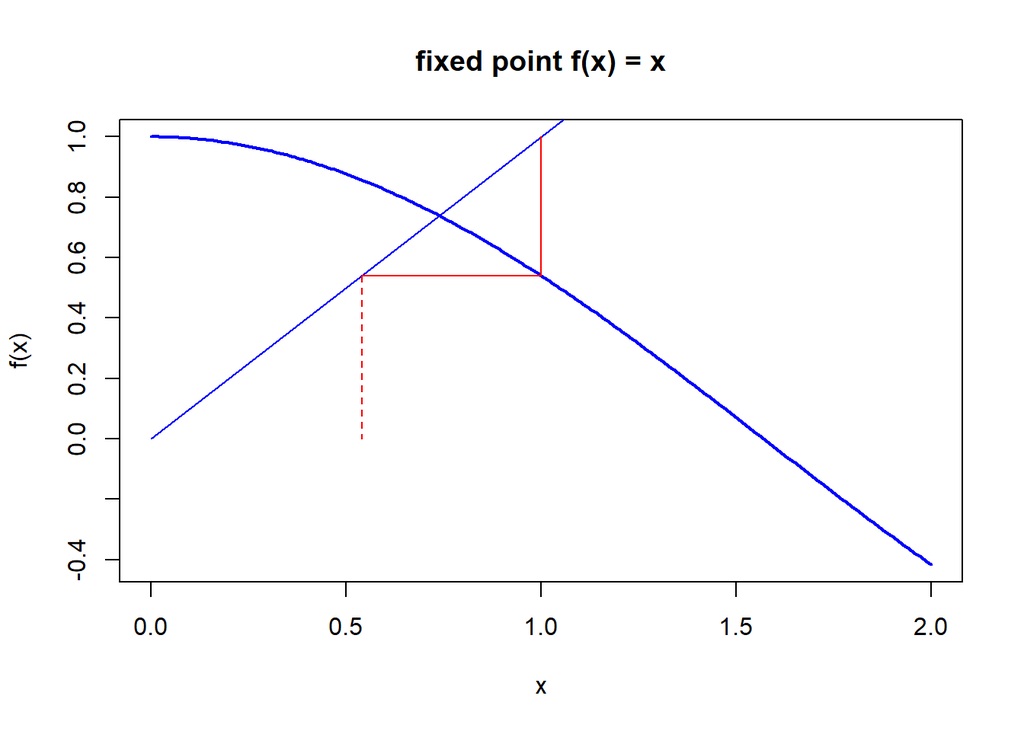

```
## last x value 0.5403023  continue (y or n)?
```

```
## [1] 0.5403023
```

```r
#a
ftn <- function(x) return(cos(x))
fixedpoint_show(ftn, 1)  #x0=1
```

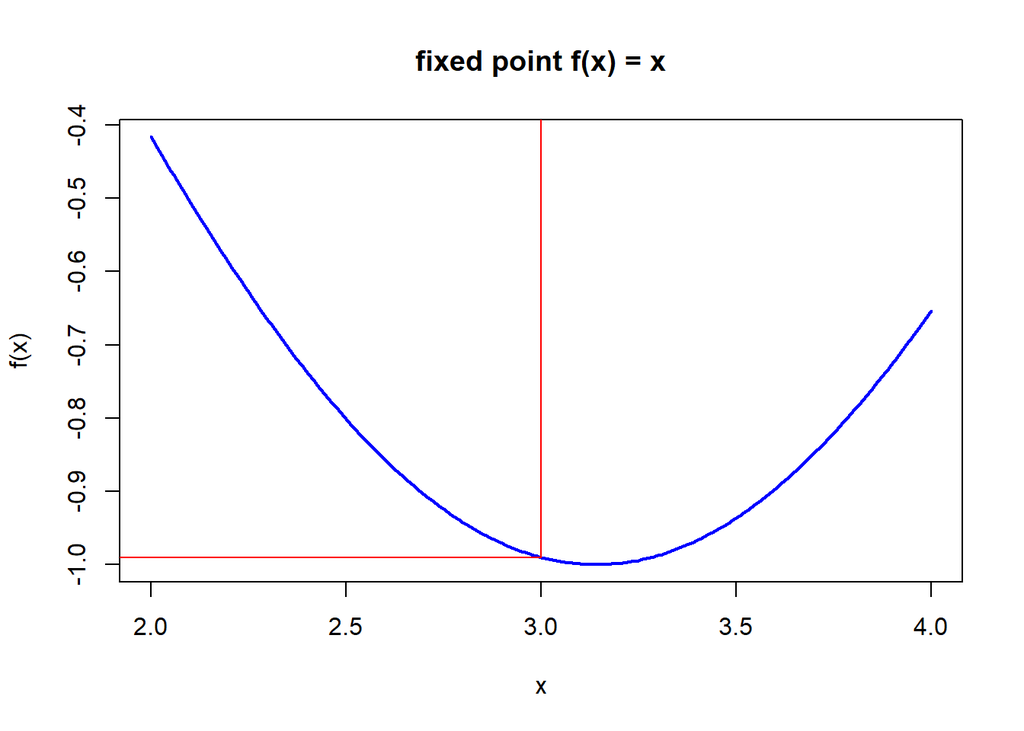

```
## last x value -0.9899925  continue (y or n)?
```

```
## [1] -0.9899925
```

```r
fixedpoint_show(ftn, 3)  #x0=3
```

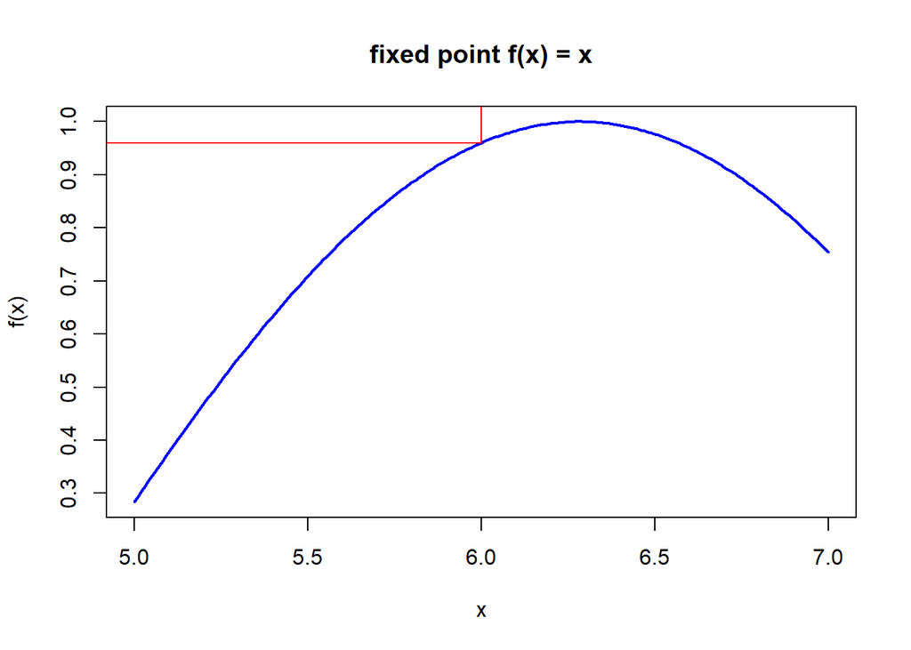

```
## last x value 0.9601703  continue (y or n)?
```

```
## [1] 0.9601703
```

```r
fixedpoint_show(ftn, 6)  #x0=6
```

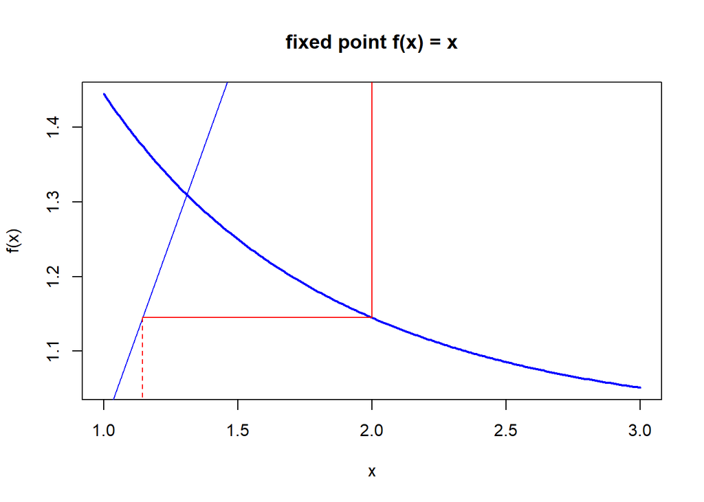

```
## last x value 1.144921  continue (y or n)?
```

```
## [1] 1.144921
```

```r
#b
ftn <- function(x) return(exp(exp(-x)))
fixedpoint_show(ftn, 2)
```

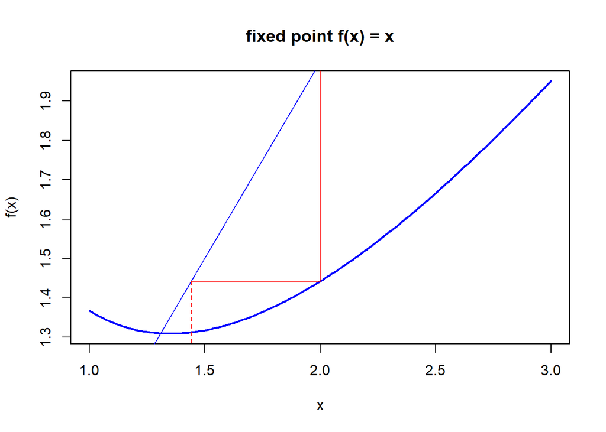

```
## last x value 1.442188  continue (y or n)?
```

```
## [1] 1.442188
```

```r
#c
ftn <- function(x) return(x-log(x)+exp(-x))
fixedpoint_show(ftn, 2)
```

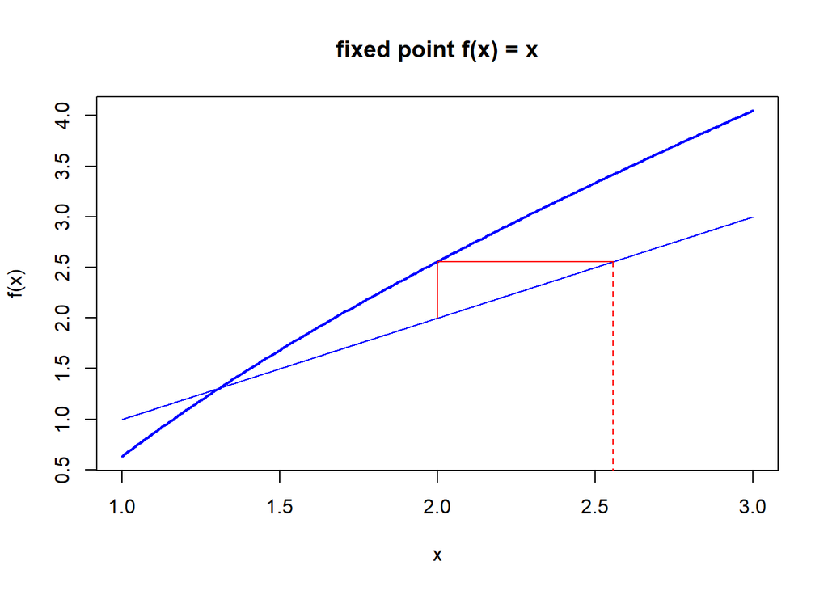

```
## last x value 2.557812  continue (y or n)?
```

```
## [1] 2.557812
```

```r
#d
ftn <- function(x) return(x+log(x)-exp(-x))
fixedpoint_show(ftn, 2)
```

## Question 5

Below is a modification of newtonraphson that plots intermediate results, analogous to fixedpoint_show above.

function:

```r
newtonraphson_show <- function(ftn, x0, xmin = x0-1, xmax = x0+1){
  x <- seq(xmin, xmax, (xmax - xmin)/200)
  fx <- c()
  for (i in 1:length(x)){
    fx[i] <- ftn(x[i])[1]
  }
  plot(x, fx, type = "l", xlab = "x", ylab = "f(x)",main = "zero f(x) = 0", col = "blue", lwd = 2)
  lines(c(xmin, xmax), c(0, 0), col = "blue")
  xold <- x0
  f.xold <- ftn(xold)
  xnew <- xold - f.xold[1]/f.xold[2]
  lines(c(xold, xold, xnew), c(0, f.xold[1], 0), col = "red")
  cat("last x value", xnew, " ")
  continue <- readline("continue (y or n)? ") == "y"
  while (continue){
    xold <- xnew;
    f.xold <- ftn(xold)
    xnew <- xold - f.xold[1]/f.xold[2]
    lines(c(xold, xold, xnew), c(0, f.xold[1], 0), col = "red")
    cat("last x value", xnew, " ")
    continue <- readline("continue (y or n)? ") == "y"
  }
  return(xnew)
}
```

Use it to investigate the roots of the following functions:  
(a). $cos(x) − x$ using $x_{0}$ = 1, 3, 6  
(b). $log(x) − exp(−x)$ using $x_{0}$ = 2  
(c). $x^{3} − x − 3$ using $x_{0}$ = 0  
(d). $x^{3} − 7x^{2} + 14x − 8$ using $x_{0}$ = 1.1, 1.2, . . ., 1.9  
(e). $log(x) exp(−x)$ using $x_{0} = 2$.

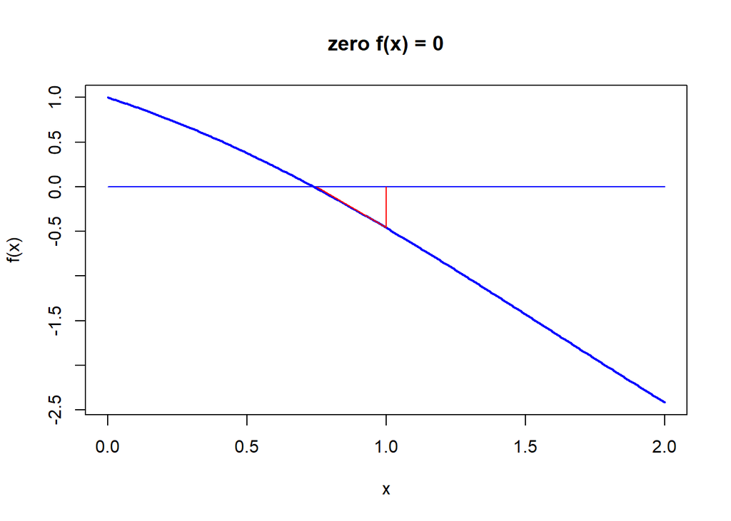

```
## last x value 0.7503639  continue (y or n)?
```

```
## [1] 0.7503639
```

```r
#a
ftn <- function(x) {
  fx <- cos(x)-x
  dfx <- -sin(x)-1
  return(c(fx, dfx))
}
newtonraphson_show(ftn, 1)  #x0=1
```

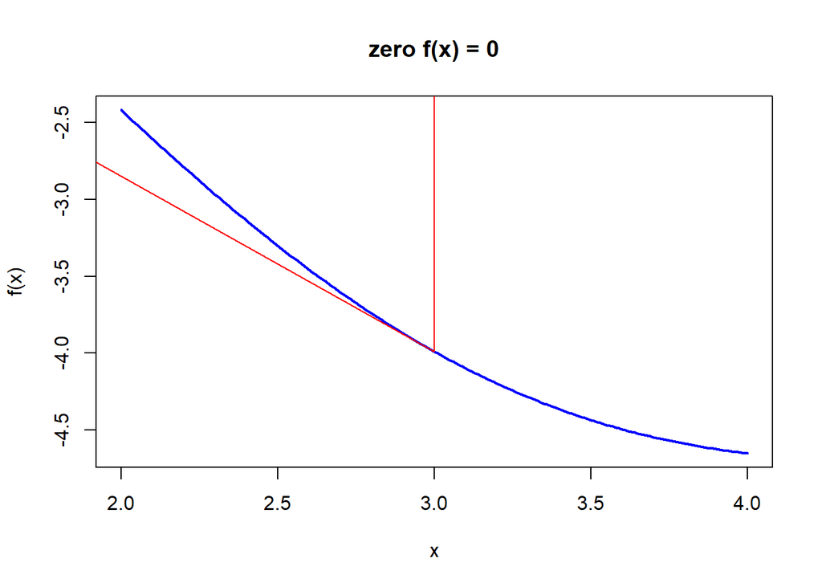

```
## last x value -0.4965582  continue (y or n)?
```

```
## [1] -0.4965582
```

```r
newtonraphson_show(ftn, 3)  #x0=3
```

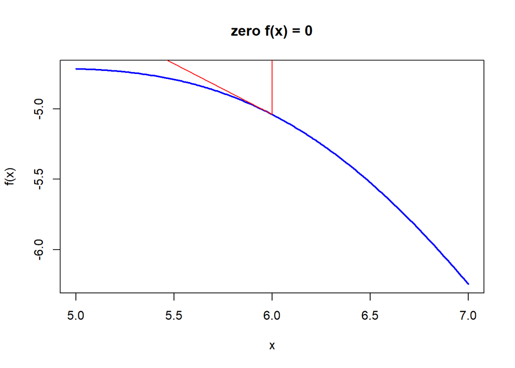

```
## last x value -0.9940856  continue (y or n)?
```

```
## [1] -0.9940856
```

```r
newtonraphson_show(ftn, 6)  #x0=6
```

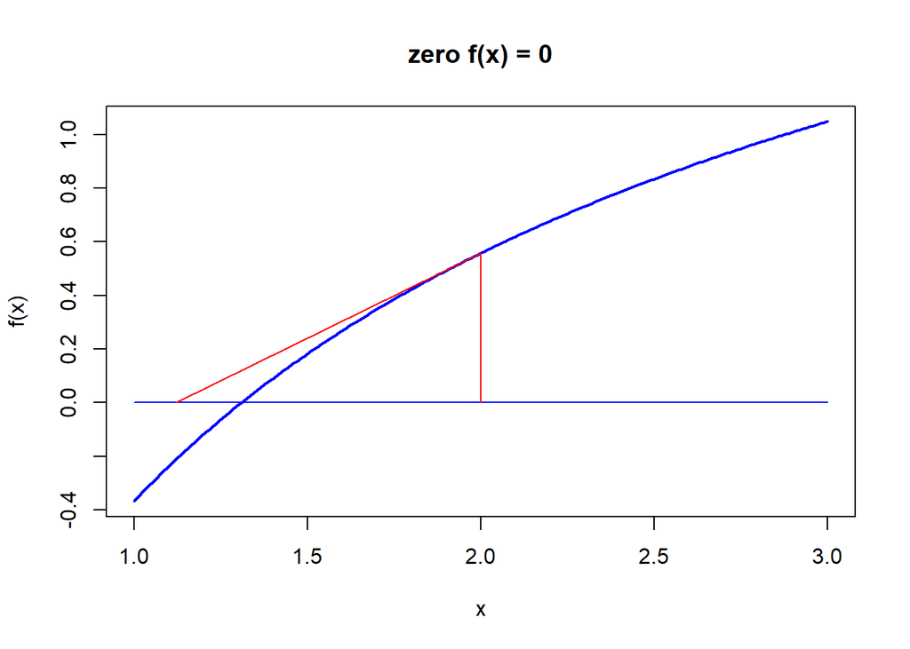

```
## last x value 1.12202  continue (y or n)?
```

```
## [1] 1.12202
```

```r
#b
ftn <- function(x) {
  fx <- log(x)-exp(-x)
  dfx <- 1/x+exp(-x)
  return(c(fx, dfx))
}
newtonraphson_show(ftn, 2)
```

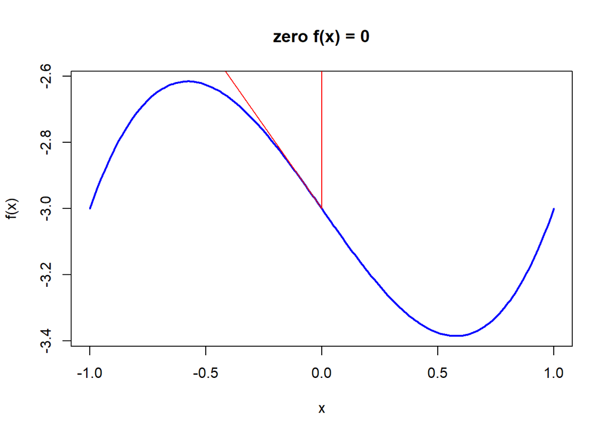

```
## last x value -3  continue (y or n)?
```

```
## [1] -3
```

```r
#c
ftn <- function(x) {
  fx <- x^{3}-x-3
  dfx <- 3*x^{2}-1
  return(c(fx, dfx))
}
newtonraphson_show(ftn, 0)
```

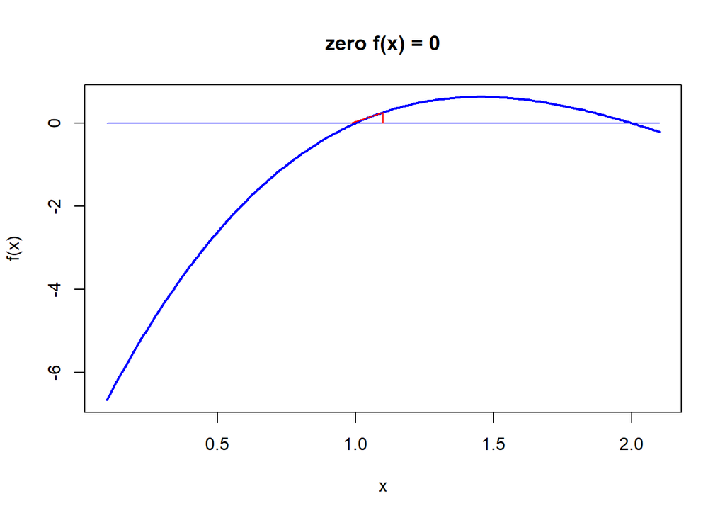

```
## last x value 0.9829596  continue (y or n)?
```

```
## [1] 0.9829596
```

```r
#d
ftn <- function(x) {
  fx <- x^{3}-7*x^{2}+14*x-8
  dfx <- 3*x^{2}-14*x+14
  return(c(fx, dfx))
}
newtonraphson_show(ftn, 1.1)  #x0=1.1
```

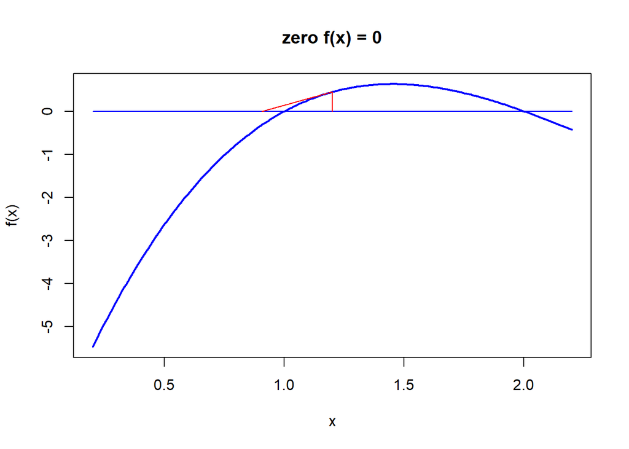

```
## last x value 0.9052632  continue (y or n)?
```

```
## [1] 0.9052632
```

```r
newtonraphson_show(ftn, 1.2)  #x0=1.2
```

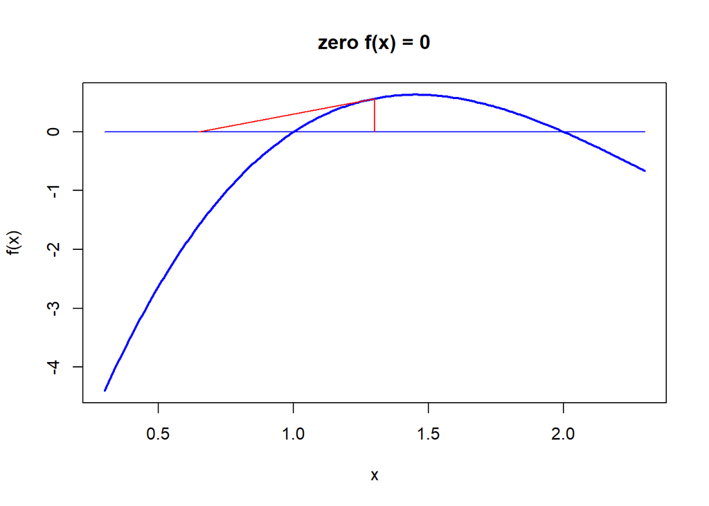

```
## last x value 0.6482759  continue (y or n)?
```

```
## [1] 0.6482759
```

```r
newtonraphson_show(ftn, 1.3)  #x0=1.3
```

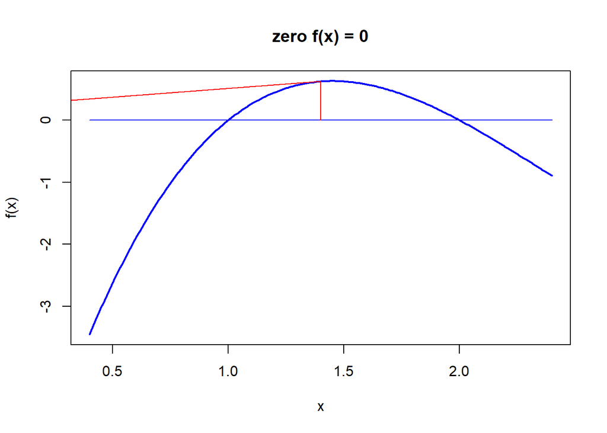

```
## last x value -0.8285714  continue (y or n)?
```

```
## [1] -0.8285714
```

```r
newtonraphson_show(ftn, 1.4)  #x0=1.4
```

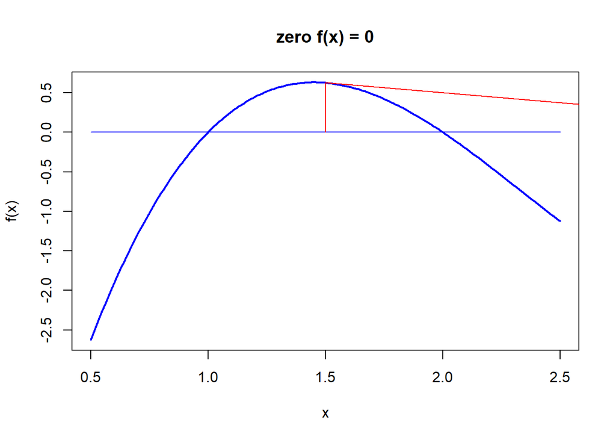

```
## last x value 4  continue (y or n)?
```

```
## [1] 4
```

```r
newtonraphson_show(ftn, 1.5)  #x0=1.5
```

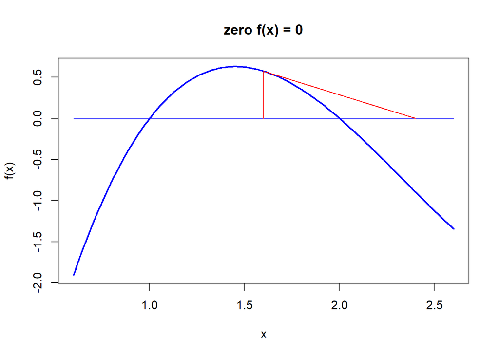

```
## last x value 2.4  continue (y or n)?
```

```
## [1] 2.4
```

```r
newtonraphson_show(ftn, 1.6)  #x0=1.6
```

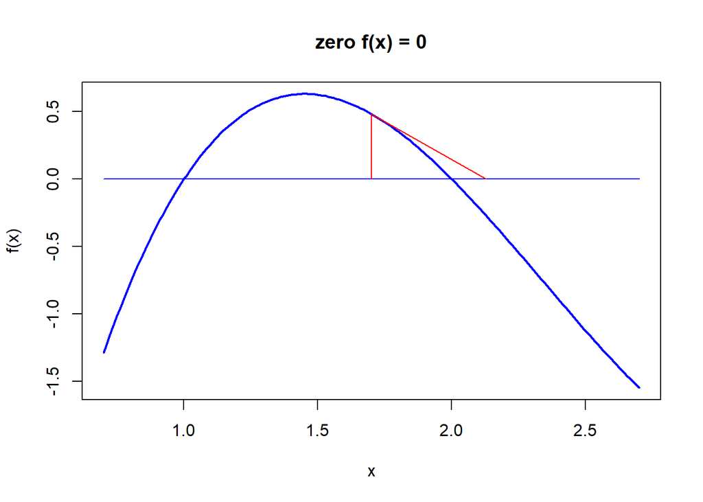

```
## last x value 2.127434  continue (y or n)?
```

```
## [1] 2.127434
```

```r
newtonraphson_show(ftn, 1.7)  #x0=1.7
```

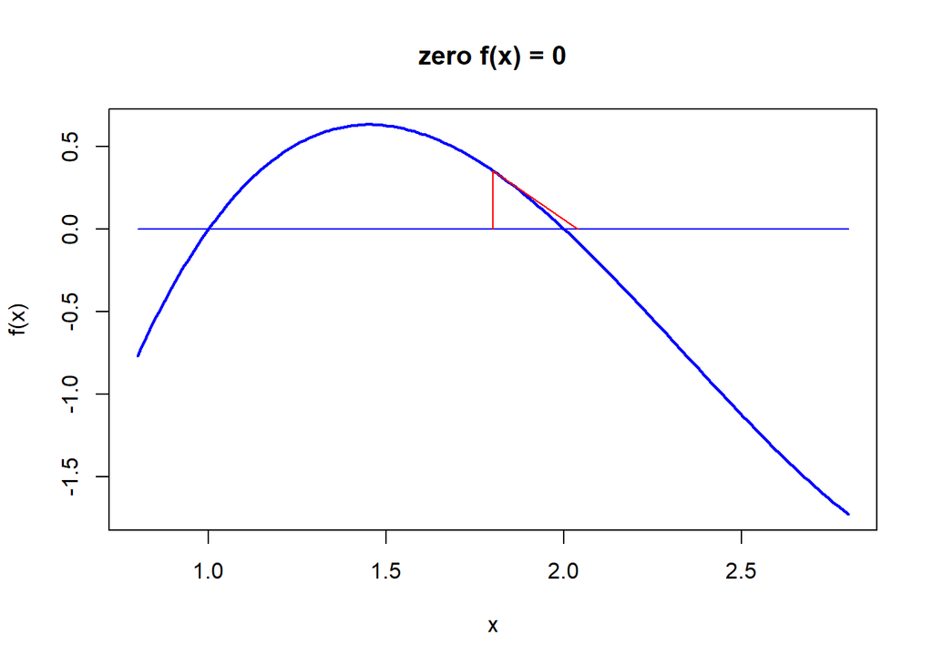

```
## last x value 2.037838  continue (y or n)?
```

```
## [1] 2.037838
```

```r
newtonraphson_show(ftn, 1.8)  #x0=1.8
```

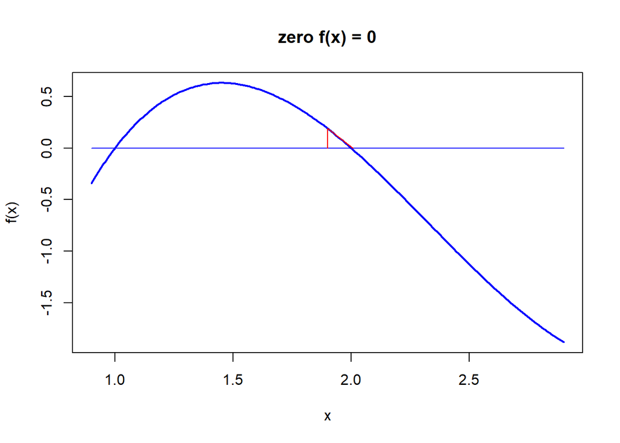

```
## last x value 2.00678  continue (y or n)?
```

```
## [1] 2.00678
```

```r
newtonraphson_show(ftn, 1.9)  #x0=1.9
```

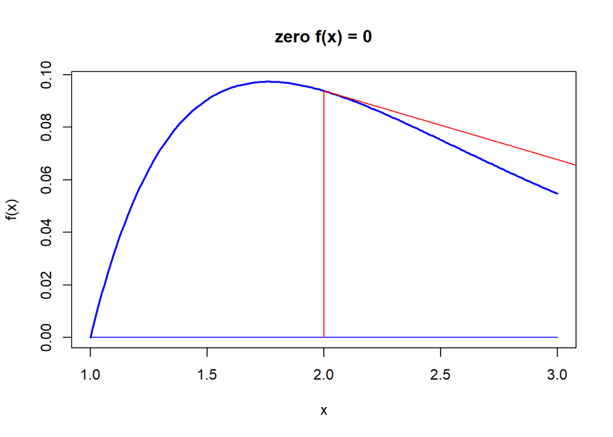

```
## last x value 5.588699  continue (y or n)?
```

```
## [1] 5.588699
```

```r
#e
ftn <- function(x) {
  fx <- log(x)*exp(-x)
  dfx <- 1/x*exp(-x)-log(x)*exp(-x)
  return(c(fx, dfx))
}
newtonraphson_show(ftn, 2)
```

## Question 6

```r
#fixedpoint
fixedpoint_show <- function(ftn, x0, xmin = x0-1, xmax = x0+1){
  x <- seq(xmin, xmax, (xmax - xmin)/200)
  fx <- sapply(x, ftn)
  plot(x, fx, type = "l", xlab = "x", ylab = "f(x)",main = "fixed point f(x) = x", col = "blue", lwd = 2)
  lines(c(xmin, xmax), c(xmin, xmax), col = "blue")
  xold <- x0
  xnew <- ftn(xold)
  lines(c(xold, xold, xnew), c(xold, xnew, xnew), col = "red")
  lines(c(xnew, xnew), c(xnew, 0), lty = 2, col = "red")
  cat("last x value", xnew, " ")
  continue <- readline("continue (y or n)? ") == "y"
  while (continue){
    xold <- xnew;
    xnew <- ftn(xold);
    lines(c(xold, xold, xnew), c(xold, xnew, xnew), col = "red")
    lines(c(xnew, xnew), c(xnew, 0), lty = 2, col = "red")
    cat("last x value", xnew, " ")
    continue <- readline("continue (y or n)? ") == "y"
  }
  return(xnew)
}

ftn1 <- function(x) return(3*sin(x/2*pi)-4*cos(x*pi))
fixedpoint(ftn1, 7, tol = 1e-06)
```

```
## At iteration 1 value of x is: 1
## At iteration 2 value of x is: 7
## At iteration 3 value of x is: 1
## At iteration 4 value of x is: 7
## At iteration 5 value of x is: 1
## At iteration 6 value of x is: 7
## At iteration 7 value of x is: 1
## At iteration 8 value of x is: 7
## At iteration 9 value of x is: 1
## At iteration 10 value of x is: 7
## At iteration 11 value of x is: 1
## At iteration 12 value of x is: 7
## At iteration 13 value of x is: 1
## At iteration 14 value of x is: 7
## At iteration 15 value of x is: 1
## At iteration 16 value of x is: 7
## At iteration 17 value of x is: 1
## At iteration 18 value of x is: 7
## At iteration 19 value of x is: 1
## At iteration 20 value of x is: 7
## At iteration 21 value of x is: 1
## At iteration 22 value of x is: 7
## At iteration 23 value of x is: 1
## At iteration 24 value of x is: 7
## At iteration 25 value of x is: 1
## At iteration 26 value of x is: 7
## At iteration 27 value of x is: 1
## At iteration 28 value of x is: 7
## At iteration 29 value of x is: 1
## At iteration 30 value of x is: 7
## At iteration 31 value of x is: 1
## At iteration 32 value of x is: 7
## At iteration 33 value of x is: 1
## At iteration 34 value of x is: 7
## At iteration 35 value of x is: 1
## At iteration 36 value of x is: 7
## At iteration 37 value of x is: 1
## At iteration 38 value of x is: 7
## At iteration 39 value of x is: 1
## At iteration 40 value of x is: 7
```

[output cut: 46 more lines]

```
## At iteration 87 value of x is: 1
## At iteration 88 value of x is: 7
## At iteration 89 value of x is: 1
## At iteration 90 value of x is: 7
## At iteration 91 value of x is: 1
## At iteration 92 value of x is: 7
## At iteration 93 value of x is: 1
## At iteration 94 value of x is: 7
## At iteration 95 value of x is: 1
## At iteration 96 value of x is: 7
## At iteration 97 value of x is: 1
## At iteration 98 value of x is: 7
## At iteration 99 value of x is: 1
## At iteration 100 value of x is: 7
## Algorithm failed to converge
```

```r
#newtonraphson
newtonraphson <- function(ftn, x0, tol = 1e-9, max.iter = 100){
  x <- x0
  fx <- ftn(x)
  iter <- 0
  while ((abs(fx[1]) > tol) && (iter < max.iter)){
    x <- x - fx[1]/fx[2]
    fx <- ftn(x)
    iter <- iter + 1
    cat("At iteration", iter, "value of x is:", x, "\n")
  }
  if (abs(fx[1]) > tol){
    cat("Algorithm failed to converge\n")
    return(NULL)
  }else{
    cat("Algorithm converged\n")
    return(x)
  }
}

ftn4 <- function(x) {
  fx <- cos(x)-x
  dfx <- -sin(x)-1
  return(c(fx, dfx))
}
newtonraphson(ftn4, 0)
```

```
## At iteration 1 value of x is: 1
## At iteration 2 value of x is: 0.7503639
## At iteration 3 value of x is: 0.7391129
## At iteration 4 value of x is: 0.7390851
## Algorithm converged
```

```
## [1] 0.7390851
```

## Question 9

For $f : R → R$, the Newton-Raphson algorithm uses a sequence of linear approximations to $f$ to find a root.  
What happens if we use quadratic approximations instead?  
Suppose that $x_{n}$ is our current approximation to $f$, then a quadratic approximation to $f$ at xn is given by the second-order Taylor expansion: $f(x) ≈ g_{n}(x) = f(x_{n} + (x − x_{n})f′(x_{n}) + \frac{1}{2}(x − x_{n})^{2}f′′(x_{n})$.  
Let $x_{n+1}$ be the solution of $g_{n}(x) = 0$ that is closest to xn, assuming a solution exists.  
If $g_{n}(x) = 0$ has no solution, then let $x_{n+1}$ be the point at which gn attains either its minimum or maximum.

End of chpater 10 exercises.